# Vector Autoregression (VAR)

This is small project to test any significant relationships in price movements between the most liquid contracts in Europe for power, gas and carbon emissions respectively. The data has been extracted from investing.com starting from 23rd January until 26th March.

ICE Dutch TTF Natural Gas Futures: https://www.investing.com/commodities/ice-dutch-ttf-gas-c1-futures German Power Baseload Calendar Month Futures: https://www.investing.com/commodities/german-power-baseload-electricity-m-futures European Union Allowance (EUA) Monthly Futures: https://www.investing.com/commodities/european-union-allowance-eua-year-futures

The power and gas prices are daily data representing the closing price of next month delivery. The carbon emissions price represents the December contract of that year which is the most liquid.

Data is divided into stationary and non-stationary. Non-stationary data is the actual prices. Stationary data represents the daily percent change in price.

The project consists of several tests that measure the usefulness of the data and the actual relationship between stationary and non-stationary data.

The end goal of the project is to measure 3 statements:

In terms of code quality, the objective is to create as less variables as possible and less loops as possible.

The plan of the project is as follows:

1. Import libraries and convert the Date column.
2. Plot stat and non-stat data.
3. Perform Granger Causality Test for direct relationships up to the 5th lag (Output is collapsable)
4. Perform Johansen Test for Cointegration.
5. Augmented Dickey-Fuller test for stationarity.
6. Plot Autocorrelation and Partial Autocorrelation for the stationary data.
7. Print summary of the VAR model
8. Perform Jarque-Bera and Shapiro-Wilk tests to check for normality of residuals.

```r
# Load necessary libraries
library(readr)
library(dplyr)
library(lubridate)
library(ggplot2)
library(vars)
library(MASS)
library(strucchange)
library(sandwich)
library(urca)
library(tseries)
library(tidyverse)
library(tidyr)
library(gridExtra)
library(lmtest)
library(nortest)

data <- read_csv("nrg_data.csv")
```

```r
data <- data %>%
  mutate(Date = as.Date(Date)) %>%
  arrange(Date)
```

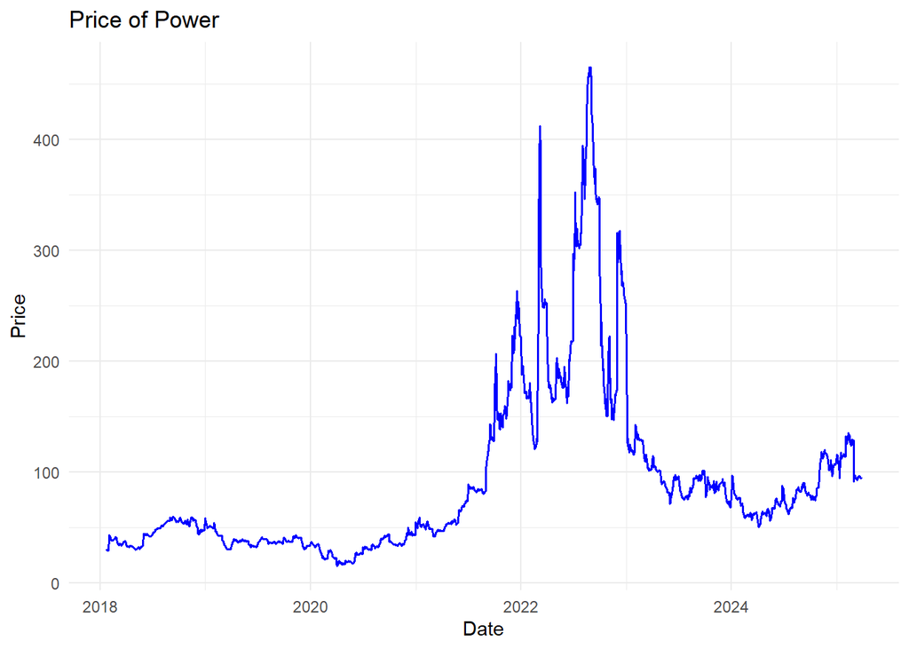

```r
ggplot(data, aes(x = as.Date(Date), y = Price_Power)) +
  geom_line(color = "blue", linewidth=0.6) +
  labs(title = "Price of Power", x = "Date", y = "Price") +
  theme_minimal()
```

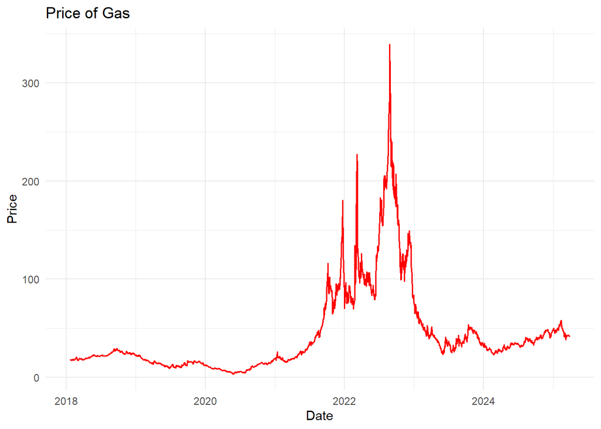

```r
ggplot(data, aes(x = as.Date(Date), y = Price_Gas)) +
  geom_line(color = "red", linewidth=0.6) +
  labs(title = "Price of Gas", x = "Date", y = "Price") +
  theme_minimal()
```

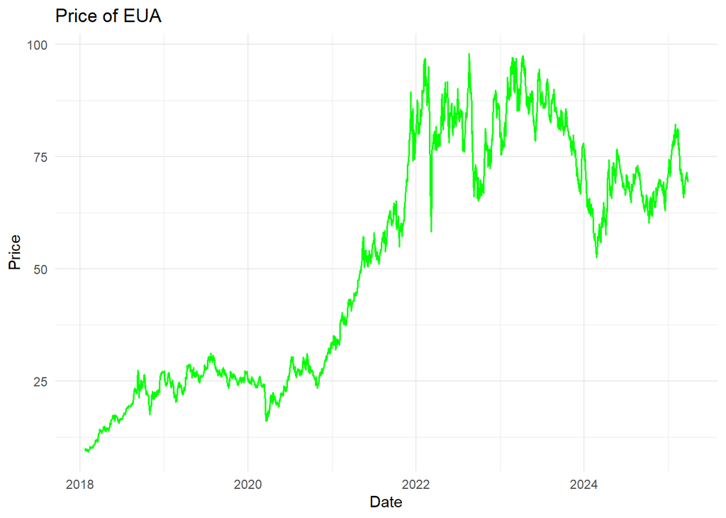

```r
ggplot(data, aes(x = as.Date(Date), y = Price_Eua)) +
  geom_line(color = "green", linewidth=0.6) +
  labs(title = "Price of EUA", x = "Date", y = "Price") +
  theme_minimal()
```

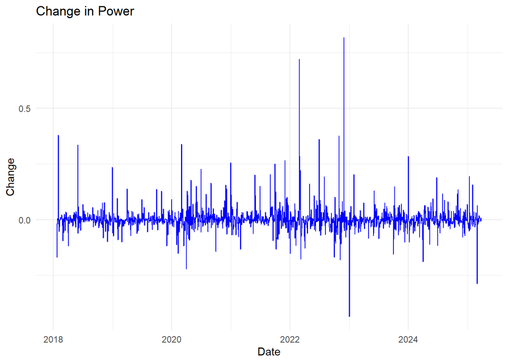

```r
# Plot Change_Eua
ggplot(data, aes(x = as.Date(Date), y = Change_power)) +
  geom_line(color = "blue") +
  labs(title = "Change in Power", x = "Date", y = "Change") +
  theme_minimal()
```

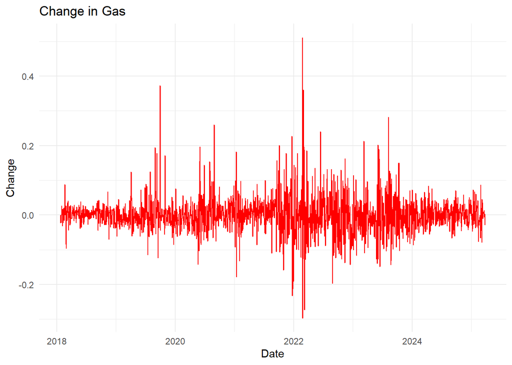

```r
# Plot Change_Gas
ggplot(data, aes(x = as.Date(Date), y = Change_gas)) +
  geom_line(color = "red") +
  labs(title = "Change in Gas", x = "Date", y = "Change") +
  theme_minimal()
```

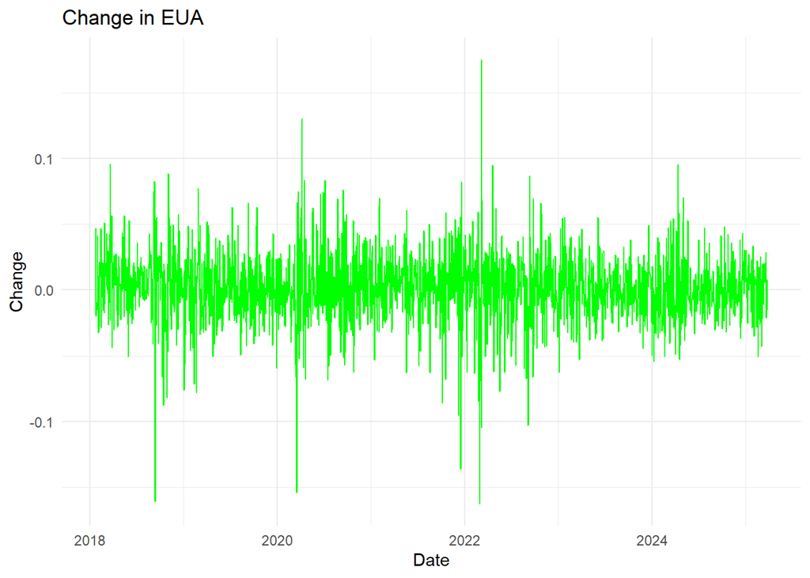

```r
# Plot Change_Eua
ggplot(data, aes(x = as.Date(Date), y = Change_eua)) +
  geom_line(color = "green") +
  labs(title = "Change in EUA", x = "Date", y = "Change") +
  theme_minimal()
```

```r
# Capture all test output
granger_results <- ""

for (lag in 1:5) {
  granger_results <- paste0(
    granger_results,
    sprintf("\nTesting if Change_gas causes Change_power (Lag %d)\n", lag),
    paste(capture.output(grangertest(Change_power ~ Change_gas, order = lag, data = data)), collapse = "\n"),

    sprintf("\nTesting if Change_power causes Change_gas (Lag %d)\n", lag),
    paste(capture.output(grangertest(Change_gas ~ Change_power, order = lag, data = data)), collapse = "\n"),

    sprintf("\nTesting if Change_gas causes Change_eua (Lag %d)\n", lag),
    paste(capture.output(grangertest(Change_eua ~ Change_gas, order = lag, data = data)), collapse = "\n"),

    sprintf("\nTesting if Change_eua causes Change_gas (Lag %d)\n", lag),
    paste(capture.output(grangertest(Change_gas ~ Change_eua, order = lag, data = data)), collapse = "\n"),

    sprintf("\nTesting if Change_power causes Change_eua (Lag %d)\n", lag),
    paste(capture.output(grangertest(Change_eua ~ Change_power, order = lag, data = data)), collapse = "\n"),

    sprintf("\nTesting if Change_eua causes Change_power (Lag %d)\n", lag),
    paste(capture.output(grangertest(Change_power ~ Change_eua, order = lag, data = data)), collapse = "\n"),

    "\n\n"
  )
}

# Safely output wrapped HTML with collapsible section
cat(paste0(
  "<details><summary><strong>Granger Causality Test Results (Click to expand)</strong></summary>\n",
  "<pre>\n",
  granger_results,
  "</pre>\n</details>\n"
))
```

**Granger Causality Test Results (Click to expand)**

```
Testing if Change_gas causes Change_power (Lag 1)
Granger causality test

Model 1: Change_power ~ Lags(Change_power, 1:1) + Lags(Change_gas, 1:1)
Model 2: Change_power ~ Lags(Change_power, 1:1)
  Res.Df Df     F    Pr(>F)
1   1782
2   1783 -1 15.51 8.523e-05 ***
---
Signif. codes:  0 '***' 0.001 '**' 0.01 '*' 0.05 '.' 0.1 ' ' 1
Testing if Change_power causes Change_gas (Lag 1)
Granger causality test

Model 1: Change_gas ~ Lags(Change_gas, 1:1) + Lags(Change_power, 1:1)
Model 2: Change_gas ~ Lags(Change_gas, 1:1)
  Res.Df Df      F   Pr(>F)
1   1782
2   1783 -1 7.0308 0.008083 **
---
Signif. codes:  0 '***' 0.001 '**' 0.01 '*' 0.05 '.' 0.1 ' ' 1
Testing if Change_gas causes Change_eua (Lag 1)
Granger causality test

Model 1: Change_eua ~ Lags(Change_eua, 1:1) + Lags(Change_gas, 1:1)
Model 2: Change_eua ~ Lags(Change_eua, 1:1)
  Res.Df Df      F  Pr(>F)
1   1782
2   1783 -1 3.6818 0.05517 .
---
Signif. codes:  0 '***' 0.001 '**' 0.01 '*' 0.05 '.' 0.1 ' ' 1
Testing if Change_eua causes Change_gas (Lag 1)
Granger causality test

Model 1: Change_gas ~ Lags(Change_gas, 1:1) + Lags(Change_eua, 1:1)
Model 2: Change_gas ~ Lags(Change_gas, 1:1)
  Res.Df Df      F Pr(>F)
1   1782
2   1783 -1 0.5398 0.4626
Testing if Change_power causes Change_eua (Lag 1)
Granger causality test

Model 1: Change_eua ~ Lags(Change_eua, 1:1) + Lags(Change_power, 1:1)
Model 2: Change_eua ~ Lags(Change_eua, 1:1)
  Res.Df Df      F Pr(>F)
1   1782
2   1783 -1 4.4518  0.035 *
---
Signif. codes:  0 '***' 0.001 '**' 0.01 '*' 0.05 '.' 0.1 ' ' 1
Testing if Change_eua causes Change_power (Lag 1)
Granger causality test

Model 1: Change_power ~ Lags(Change_power, 1:1) + Lags(Change_eua, 1:1)
Model 2: Change_power ~ Lags(Change_power, 1:1)
  Res.Df Df      F Pr(>F)
1   1782
2   1783 -1 0.9629 0.3266


Testing if Change_gas causes Change_power (Lag 2)
Granger causality test

Model 1: Change_power ~ Lags(Change_power, 1:2) + Lags(Change_gas, 1:2)
Model 2: Change_power ~ Lags(Change_power, 1:2)
  Res.Df Df      F    Pr(>F)
1   1779
2   1781 -2 9.2935 9.656e-05 ***
---
Signif. codes:  0 '***' 0.001 '**' 0.01 '*' 0.05 '.' 0.1 ' ' 1
Testing if Change_power causes Change_gas (Lag 2)
Granger causality test

Model 1: Change_gas ~ Lags(Change_gas, 1:2) + Lags(Change_power, 1:2)
Model 2: Change_gas ~ Lags(Change_gas, 1:2)
  Res.Df Df      F    Pr(>F)
1   1779
2   1781 -2 10.295 3.587e-05 ***
---
Signif. codes:  0 '***' 0.001 '**' 0.01 '*' 0.05 '.' 0.1 ' ' 1
Testing if Change_gas causes Change_eua (Lag 2)
Granger causality test

Model 1: Change_eua ~ Lags(Change_eua, 1:2) + Lags(Change_gas, 1:2)
Model 2: Change_eua ~ Lags(Change_eua, 1:2)
  Res.Df Df      F Pr(>F)
1   1779
2   1781 -2 1.8736 0.1539
Testing if Change_eua causes Change_gas (Lag 2)
Granger causality test

Model 1: Change_gas ~ Lags(Change_gas, 1:2) + Lags(Change_eua, 1:2)
Model 2: Change_gas ~ Lags(Change_gas, 1:2)
  Res.Df Df      F Pr(>F)
1   1779
2   1781 -2 0.5254 0.5914
Testing if Change_power causes Change_eua (Lag 2)
Granger causality test

Model 1: Change_eua ~ Lags(Change_eua, 1:2) + Lags(Change_power, 1:2)
Model 2: Change_eua ~ Lags(Change_eua, 1:2)
  Res.Df Df      F  Pr(>F)
1   1779
2   1781 -2 3.4659 0.03146 *
---
Signif. codes:  0 '***' 0.001 '**' 0.01 '*' 0.05 '.' 0.1 ' ' 1
Testing if Change_eua causes Change_power (Lag 2)
Granger causality test

Model 1: Change_power ~ Lags(Change_power, 1:2) + Lags(Change_eua, 1:2)
Model 2: Change_power ~ Lags(Change_power, 1:2)
  Res.Df Df      F Pr(>F)
1   1779
2   1781 -2 0.8058 0.4469


Testing if Change_gas causes Change_power (Lag 3)
Granger causality test

Model 1: Change_power ~ Lags(Change_power, 1:3) + Lags(Change_gas, 1:3)
Model 2: Change_power ~ Lags(Change_power, 1:3)
  Res.Df Df      F    Pr(>F)
1   1776
2   1779 -3 6.2108 0.0003402 ***
---
Signif. codes:  0 '***' 0.001 '**' 0.01 '*' 0.05 '.' 0.1 ' ' 1
Testing if Change_power causes Change_gas (Lag 3)
Granger causality test

Model 1: Change_gas ~ Lags(Change_gas, 1:3) + Lags(Change_power, 1:3)
Model 2: Change_gas ~ Lags(Change_gas, 1:3)
  Res.Df Df      F    Pr(>F)
1   1776
2   1779 -3 7.9065 3.073e-05 ***
---
Signif. codes:  0 '***' 0.001 '**' 0.01 '*' 0.05 '.' 0.1 ' ' 1
Testing if Change_gas causes Change_eua (Lag 3)
Granger causality test

Model 1: Change_eua ~ Lags(Change_eua, 1:3) + Lags(Change_gas, 1:3)
Model 2: Change_eua ~ Lags(Change_eua, 1:3)
  Res.Df Df      F   Pr(>F)
1   1776
2   1779 -3 4.4042 0.004288 **
---
Signif. codes:  0 '***' 0.001 '**' 0.01 '*' 0.05 '.' 0.1 ' ' 1
Testing if Change_eua causes Change_gas (Lag 3)
Granger causality test

Model 1: Change_gas ~ Lags(Change_gas, 1:3) + Lags(Change_eua, 1:3)
Model 2: Change_gas ~ Lags(Change_gas, 1:3)
  Res.Df Df      F Pr(>F)
1   1776
2   1779 -3 0.3702 0.7746
Testing if Change_power causes Change_eua (Lag 3)
Granger causality test

Model 1: Change_eua ~ Lags(Change_eua, 1:3) + Lags(Change_power, 1:3)
Model 2: Change_eua ~ Lags(Change_eua, 1:3)
  Res.Df Df      F  Pr(>F)
1   1776
2   1779 -3 2.4032 0.06588 .
---
Signif. codes:  0 '***' 0.001 '**' 0.01 '*' 0.05 '.' 0.1 ' ' 1
Testing if Change_eua causes Change_power (Lag 3)
Granger causality test

Model 1: Change_power ~ Lags(Change_power, 1:3) + Lags(Change_eua, 1:3)
Model 2: Change_power ~ Lags(Change_power, 1:3)
  Res.Df Df      F Pr(>F)
1   1776
2   1779 -3 1.6866 0.1679


Testing if Change_gas causes Change_power (Lag 4)
Granger causality test

Model 1: Change_power ~ Lags(Change_power, 1:4) + Lags(Change_gas, 1:4)
Model 2: Change_power ~ Lags(Change_power, 1:4)
  Res.Df Df     F    Pr(>F)
1   1773
2   1777 -4 9.193 2.375e-07 ***
---
Signif. codes:  0 '***' 0.001 '**' 0.01 '*' 0.05 '.' 0.1 ' ' 1
Testing if Change_power causes Change_gas (Lag 4)
Granger causality test

Model 1: Change_gas ~ Lags(Change_gas, 1:4) + Lags(Change_power, 1:4)
Model 2: Change_gas ~ Lags(Change_gas, 1:4)
  Res.Df Df      F    Pr(>F)
1   1773
2   1777 -4 4.7802 0.0007757 ***
---
Signif. codes:  0 '***' 0.001 '**' 0.01 '*' 0.05 '.' 0.1 ' ' 1
Testing if Change_gas causes Change_eua (Lag 4)
Granger causality test

Model 1: Change_eua ~ Lags(Change_eua, 1:4) + Lags(Change_gas, 1:4)
Model 2: Change_eua ~ Lags(Change_eua, 1:4)
  Res.Df Df      F   Pr(>F)
1   1773
2   1777 -4 3.6095 0.006156 **
---
Signif. codes:  0 '***' 0.001 '**' 0.01 '*' 0.05 '.' 0.1 ' ' 1
Testing if Change_eua causes Change_gas (Lag 4)
Granger causality test

Model 1: Change_gas ~ Lags(Change_gas, 1:4) + Lags(Change_eua, 1:4)
Model 2: Change_gas ~ Lags(Change_gas, 1:4)
  Res.Df Df      F Pr(>F)
1   1773
2   1777 -4 0.6142 0.6525
Testing if Change_power causes Change_eua (Lag 4)
Granger causality test

Model 1: Change_eua ~ Lags(Change_eua, 1:4) + Lags(Change_power, 1:4)
Model 2: Change_eua ~ Lags(Change_eua, 1:4)
  Res.Df Df      F  Pr(>F)
1   1773
2   1777 -4 2.6039 0.03434 *
---
Signif. codes:  0 '***' 0.001 '**' 0.01 '*' 0.05 '.' 0.1 ' ' 1
Testing if Change_eua causes Change_power (Lag 4)
Granger causality test

Model 1: Change_power ~ Lags(Change_power, 1:4) + Lags(Change_eua, 1:4)
Model 2: Change_power ~ Lags(Change_power, 1:4)
  Res.Df Df     F Pr(>F)
1   1773
2   1777 -4 1.483 0.2048


Testing if Change_gas causes Change_power (Lag 5)
Granger causality test

Model 1: Change_power ~ Lags(Change_power, 1:5) + Lags(Change_gas, 1:5)
Model 2: Change_power ~ Lags(Change_power, 1:5)
  Res.Df Df      F    Pr(>F)
1   1770
2   1775 -5 7.7563 3.142e-07 ***
---
Signif. codes:  0 '***' 0.001 '**' 0.01 '*' 0.05 '.' 0.1 ' ' 1
Testing if Change_power causes Change_gas (Lag 5)
Granger causality test

Model 1: Change_gas ~ Lags(Change_gas, 1:5) + Lags(Change_power, 1:5)
Model 2: Change_gas ~ Lags(Change_gas, 1:5)
  Res.Df Df      F    Pr(>F)
1   1770
2   1775 -5 4.3513 0.0006122 ***
---
Signif. codes:  0 '***' 0.001 '**' 0.01 '*' 0.05 '.' 0.1 ' ' 1
Testing if Change_gas causes Change_eua (Lag 5)
Granger causality test

Model 1: Change_eua ~ Lags(Change_eua, 1:5) + Lags(Change_gas, 1:5)
Model 2: Change_eua ~ Lags(Change_eua, 1:5)
  Res.Df Df      F   Pr(>F)
1   1770
2   1775 -5 3.0885 0.008824 **
---
Signif. codes:  0 '***' 0.001 '**' 0.01 '*' 0.05 '.' 0.1 ' ' 1
Testing if Change_eua causes Change_gas (Lag 5)
Granger causality test

Model 1: Change_gas ~ Lags(Change_gas, 1:5) + Lags(Change_eua, 1:5)
Model 2: Change_gas ~ Lags(Change_gas, 1:5)
  Res.Df Df     F Pr(>F)
1   1770
2   1775 -5 0.593 0.7054
Testing if Change_power causes Change_eua (Lag 5)
Granger causality test

Model 1: Change_eua ~ Lags(Change_eua, 1:5) + Lags(Change_power, 1:5)
Model 2: Change_eua ~ Lags(Change_eua, 1:5)
  Res.Df Df      F  Pr(>F)
1   1770
2   1775 -5 2.3006 0.04273 *
---
Signif. codes:  0 '***' 0.001 '**' 0.01 '*' 0.05 '.' 0.1 ' ' 1
Testing if Change_eua causes Change_power (Lag 5)
Granger causality test

Model 1: Change_power ~ Lags(Change_power, 1:5) + Lags(Change_eua, 1:5)
Model 2: Change_power ~ Lags(Change_power, 1:5)
  Res.Df Df     F Pr(>F)
1   1770
2   1775 -5 1.599 0.1571
```

In contrast, EUA price changes do not Granger-cause changes in power prices across any lags. Overall, gas and power show the strongest interdependence, while EUA is more of a receiver than an influencer in this system. This is what was expected from the data. EUA naturally driven by the amount of gas burnt in the atmosphere. High demand spikes are naturally caused either by increased demand or reduced supply. If we assume supply is constantly seasonal then spikes in demand for electricity should determine the price and henceforth the price of EUA. The reverse relationship is not present.

```r
# Perform the Johansen Cointegration Test on columns from the existing data frame
johansen_test <- ca.jo(data[, c("Price_Gas", "Price_Power", "Price_Eua")],
                       type = "trace", ecdet = "const", K = 2)

# Display the summary of the test
summary(johansen_test)
```

```
##
## ######################
## # Johansen-Procedure #
## ######################
##
## Test type: trace statistic , without linear trend and constant in cointegration
##
## Eigenvalues (lambda):
## [1]  7.034661e-02  6.480374e-03  1.918347e-03 -3.342784e-18
##
## Values of teststatistic and critical values of test:
##
##            test 10pct  5pct  1pct
## r <= 2 |   3.43  7.52  9.24 12.97
## r <= 1 |  15.02 17.85 19.96 24.60
## r = 0  | 145.16 32.00 34.91 41.07
##
## Eigenvectors, normalised to first column:
## (These are the cointegration relations)
##
##                Price_Gas.l2 Price_Power.l2  Price_Eua.l2     constant
## Price_Gas.l2      1.0000000      1.0000000     1.0000000     1.000000
## Price_Power.l2   -0.6092453      0.4670422     0.6814755     8.073394
## Price_Eua.l2      0.1685424     -2.2093332    22.9786441   131.771463
## constant          3.2531831     27.3386795 -1720.4192174 -1331.157466
##
## Weights W:
## (This is the loading matrix)
##
##                Price_Gas.l2 Price_Power.l2  Price_Eua.l2     constant
## Price_Gas.d   -0.0527698510  -0.0058808227 -2.427016e-05 1.361529e-20
## Price_Power.d  0.1426035324  -0.0073020662 -3.950354e-05 1.969990e-19
## Price_Eua.d    0.0004240577   0.0001520143 -8.433930e-05 6.507957e-21
```

```r
# Perform ADF test on specific columns (Price_Gas.l2, Price_Power.l2, Price_Eua.l2)
adf_results <- apply(data[, c("Change_gas", "Change_power", "Change_eua")], 2, function(x) suppressWarnings(adf.test(x, alternative = "stationary")))

# View the results
adf_results
```

```
## $Change_gas
##
##  Augmented Dickey-Fuller Test
##
## data:  x
## Dickey-Fuller = -12.416, Lag order = 12, p-value = 0.01
## alternative hypothesis: stationary
##
##
## $Change_power
##
##  Augmented Dickey-Fuller Test
##
## data:  x
## Dickey-Fuller = -12.273, Lag order = 12, p-value = 0.01
## alternative hypothesis: stationary
##
##
## $Change_eua
##
##  Augmented Dickey-Fuller Test
##
## data:  x
## Dickey-Fuller = -12.603, Lag order = 12, p-value = 0.01
## alternative hypothesis: stationary
```

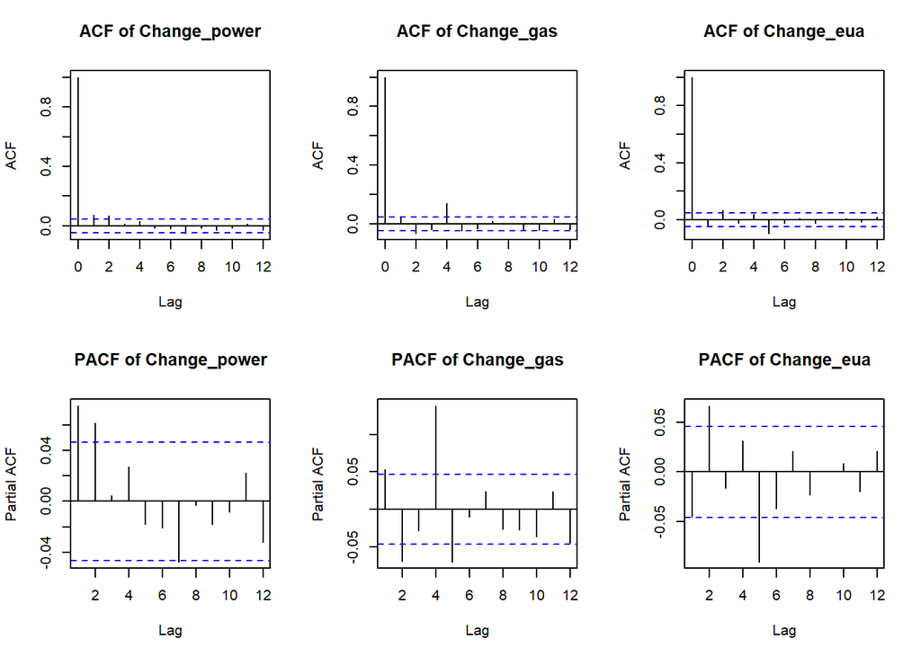

```r
# Load necessary libraries

# Create a 2-row, 3-column plot layout
par(mfrow = c(2, 3))

# Plot ACF (Autocorrelation Function) for Change_power
acf(data$Change_power, lag.max = 12, main = "ACF of Change_power")

# Plot ACF (Autocorrelation Function) for Change_gas
acf(data$Change_gas, lag.max = 12, main = "ACF of Change_gas")

# Plot ACF (Autocorrelation Function) for Change_eua
acf(data$Change_eua, lag.max = 12, main = "ACF of Change_eua")

# Plot PACF (Partial Autocorrelation Function) for Change_power
pacf(data$Change_power, lag.max = 12, main = "PACF of Change_power")

# Plot PACF (Partial Autocorrelation Function) for Change_gas
pacf(data$Change_gas, lag.max = 12, main = "PACF of Change_gas")

# Plot PACF (Partial Autocorrelation Function) for Change_eua
pacf(data$Change_eua, lag.max = 12, main = "PACF of Change_eua")
```

It also tells us that in our VAR model it would be better if we used more than one lag.

```r
  # For Jarque-Bera test
  # For Anderson-Darling test


var_model <- VAR(data[, c("Change_gas", "Change_power", "Change_eua")], p = 3)

# Extract residuals from the VAR model
residuals_var <- residuals(var_model)
summary(var_model)
```

```
##
## VAR Estimation Results:
## =========================
## Endogenous variables: Change_gas, Change_power, Change_eua
## Deterministic variables: const
## Sample size: 1783
## Log Likelihood: 9466.589
## Roots of the characteristic polynomial:
## 0.4561 0.4561 0.3732 0.362 0.362 0.3077 0.3077 0.2548 0.2548
## Call:
## VAR(y = data[, c("Change_gas", "Change_power", "Change_eua")],
##     p = 3)
##
##
## Estimation results for equation Change_gas:
## ===========================================
## Change_gas = Change_gas.l1 + Change_power.l1 + Change_eua.l1 + Change_gas.l2 + Change_power.l2 + Change_eua.l2 + Change_gas.l3 + Change_power.l3 + Change_eua.l3 + const
##
##                  Estimate Std. Error t value Pr(>|t|)
## Change_gas.l1    0.025460   0.025734   0.989 0.322615
## Change_power.l1  0.077288   0.025411   3.041 0.002389 **
## Change_eua.l1   -0.037724   0.047636  -0.792 0.428509
## Change_gas.l2   -0.108044   0.025648  -4.213 2.65e-05 ***
## Change_power.l2  0.090403   0.025384   3.561 0.000378 ***
## Change_eua.l2    0.010493   0.047492   0.221 0.825158
## Change_gas.l3   -0.050334   0.025821  -1.949 0.051408 .
## Change_power.l3  0.026466   0.025248   1.048 0.294676
## Change_eua.l3   -0.020298   0.047390  -0.428 0.668473
## const            0.001827   0.001272   1.436 0.151116
## ---
## Signif. codes:  0 '***' 0.001 '**' 0.01 '*' 0.05 '.' 0.1 ' ' 1
##
##
## Residual standard error: 0.05339 on 1773 degrees of freedom
## Multiple R-Squared: 0.02199, Adjusted R-squared: 0.01702
## F-statistic: 4.428 on 9 and 1773 DF,  p-value: 9.39e-06
##
##
## Estimation results for equation Change_power:
## =============================================
```

[output cut: 43 more lines]

```
## F-statistic:  3.57 on 9 and 1773 DF,  p-value: 0.0002069
##
##
##
## Covariance matrix of residuals:
##              Change_gas Change_power Change_eua
## Change_gas    0.0028506    0.0009592  0.0003261
## Change_power  0.0009592    0.0028070  0.0001573
## Change_eua    0.0003261    0.0001573  0.0007431
##
## Correlation matrix of residuals:
##              Change_gas Change_power Change_eua
## Change_gas       1.0000       0.3391     0.2241
## Change_power     0.3391       1.0000     0.1089
## Change_eua       0.2241       0.1089     1.0000
```

```r
# Perform Shapiro-Wilk Test on residuals for each variable
shapiro_results <- apply(residuals_var, 2, function(x) shapiro.test(x))

# Perform Jarque-Bera Test on residuals for each variable
jb_results <- apply(residuals_var, 2, function(x) jarque.bera.test(x))

# Output the results of the Shapiro-Wilk test
shapiro_results
```

```
## $Change_gas
##
##  Shapiro-Wilk normality test
##
## data:  x
## W = 0.90886, p-value < 2.2e-16
##
##
## $Change_power
##
##  Shapiro-Wilk normality test
##
## data:  x
## W = 0.65214, p-value < 2.2e-16
##
##
## $Change_eua
##
##  Shapiro-Wilk normality test
##
## data:  x
## W = 0.97139, p-value < 2.2e-16
```

```r
# Output the results of the Jarque-Bera test
jb_results
```

```
## $Change_gas
##
##  Jarque Bera Test
##
## data:  x
## X-squared = 6830.7, df = 2, p-value < 2.2e-16
##
##
## $Change_power
##
##  Jarque Bera Test
##
## data:  x
## X-squared = 259345, df = 2, p-value < 2.2e-16
##
##
## $Change_eua
##
##  Jarque Bera Test
##
## data:  x
## X-squared = 806.25, df = 2, p-value < 2.2e-16
```

# Equation-by-Equation Interpretation

## Change_gas

**Significant predictors:** - `Change_power.l1` (p = 0.002): previous period power returns affect gas. - `Change_gas.l2` (p < 0.001): significant autocorrelation. - `Change_power.l2` (p < 0.001) - `Change_gas.l3` is marginally significant (p ≈ 0.051)

**Interpretation:** Suggests strong influence from both own lags and power price movements.  
**R² = 2.2%** → low explanatory power, typical for high-frequency returns.

## Change_power

**Significant predictors:** - `Change_gas.l1` (p < 0.001) - `Change_gas.l2` (p = 0.028): gas impacts power with some lag. - `Change_eua.l3` is marginally significant (p ≈ 0.050)

**Interpretation:** Gas price movements lead power prices.  
**R² = 2.2%** → again, modest but expected for differenced data.

## Change_eua

**Significant predictors:** - `Change_power.l2` (p = 0.035) - `Change_eua.l2` (p = 0.009) - `Change_gas.l3` (p = 0.0017) - `const` (p = 0.018)

**Interpretation:** EUA dynamics seem more affected by power/gas with a delay.  
**R² = 1.78%**

The project also confirmed the initial hypotheses: strong two-way relationship between power and gas and a lot less significant of EUA to power and gas.